# Coursework Report

*N* removed NAs: 3

*N* removed typo: 1

*N* removed <18: 23

*N* total clean: 123

| Group | *N* | *M*<sub>age</sub> | *M*<sub>rating</sub> |
| --- | --- | --- | --- |
| Control | 64 | 20.6 | 6.60 |
| Experim | 59 | 20.8 | 5.45 |

**Main analysis results**

*t*(121) = 7.56, *p* < .001

[interactive chart not shown]

[figure not shown]

[interactive chart not shown]

# Coursework Report

Analysing Data, Spring 2020

This experimentation was a replication of Experiment 1 implemented in ‘Red, Rank, and Romance in Women viewing Men’ (Elliot et al., 2010), analysing the influence of colour on women’s perceptions of attractiveness, red being the respective focal colour during this first experiment.

# Methods

## Participants

150 females participated in the experiment. 23 participants were removed from the data set due to being under 18a A further 4 were also accordingly removed as these participants did not state their age and therefore could not be verified as over the age of 18. The final participant number for this experiment was 123, comprised of a mean age of 20.68 years (range = 18-29) and standard deviation of 2.15.

*Figure 1.* Participant descriptive table.

| Condition | Mean Age | Standard Deviation | Minimum Age | Maximum Age |
| --- | --- | --- | --- | --- |
| control | 20.6 | 2.04 | 18 | 29 |
| experimental | 20.8 | 2.27 | 18 | 28 |

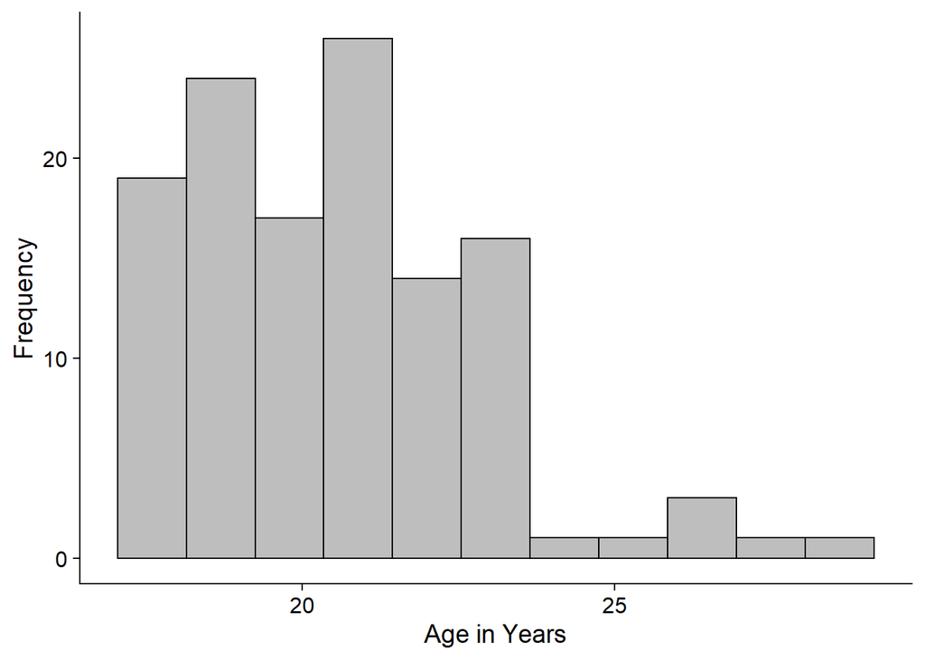

*Figure 2.* Distribution of all participants in both conditions.

## Design

Does colour influence attractiveness? As performed in the primary study, participants viewed a black and white photo of a man on either a red (n = 59) or a white (n = 64) background and expressed how attractive they found the subject based on a numerical rating, 1-9: 1 indicating ‘not at all attractive’ through 9, ’extremely attractive. Ratings were in response to 3 individual questions: “How attractive do you think this person is?”, “How pleasant is this person to look at?”, “If I were to meet the person in this picture face to face, I would think he is attractive.” An outcome could be obtained through composite scores for participants ratings which could then be compiled to establish an overall average rating of perceived attraction between colour conditions.

colour: independent categorical variable

attractiveness: continuous variable

White was used as a neutral colour to contrast red as Elliot et al. state ’white is the most unobtrusive of the achromatic colours in this experimental paradigm. ’Replicating original materials, the photo measured a 4-inch x 6-inch head and upper torso shot of a moderately attractive man. The photo was centred on an 8.5-inch x 11-inch page with the colour condition placed on the surrounding area. The variable subject to change was that of the condition (factor). Participants, unaware, were assigned the control (white), or experimental (red). An operational hypothesis for this study can be defined as; Does a coloured frame around an image of a man influence women’s mean ratings of his perceived attractiveness?

Results from the original study (Elliot et al., 2010) used 21 female participants; red (n = 10), white (n = 11), average age 20.19 years (range = 18-25). The study concluded with significant effect of colour on perceived attractiveness; red (M = 6.79, SD = 1.00), white (M = 5.67, SD = 1.34). Replicating the study shall test the validity as studies have previously.

# Results

Contradictory to the original study using an independent-measures t-test this experiment showed that the red condition did not increase attraction compared to the white condition, (*t* = 7.56, *df* = 121, *p* < .01). In contradiction, participants in the control (white) condition perceived the subject as more attractive compared with those in the experimental (red) condition; (*M* = 6.60, *SD* = 0.81, and *M* = 5.45, *SD* 0.88) respectively.

*Figure 3.* a table showing participant result descriptive

| Condition | Mean Score | Standard Deviation | Minimum Score | Maximum Score |
| --- | --- | --- | --- | --- |
| control | 6.60 | 0.81 | 4.67 | 8.33 |
| experimental | 5.45 | 0.88 | 3.33 | 7.33 |

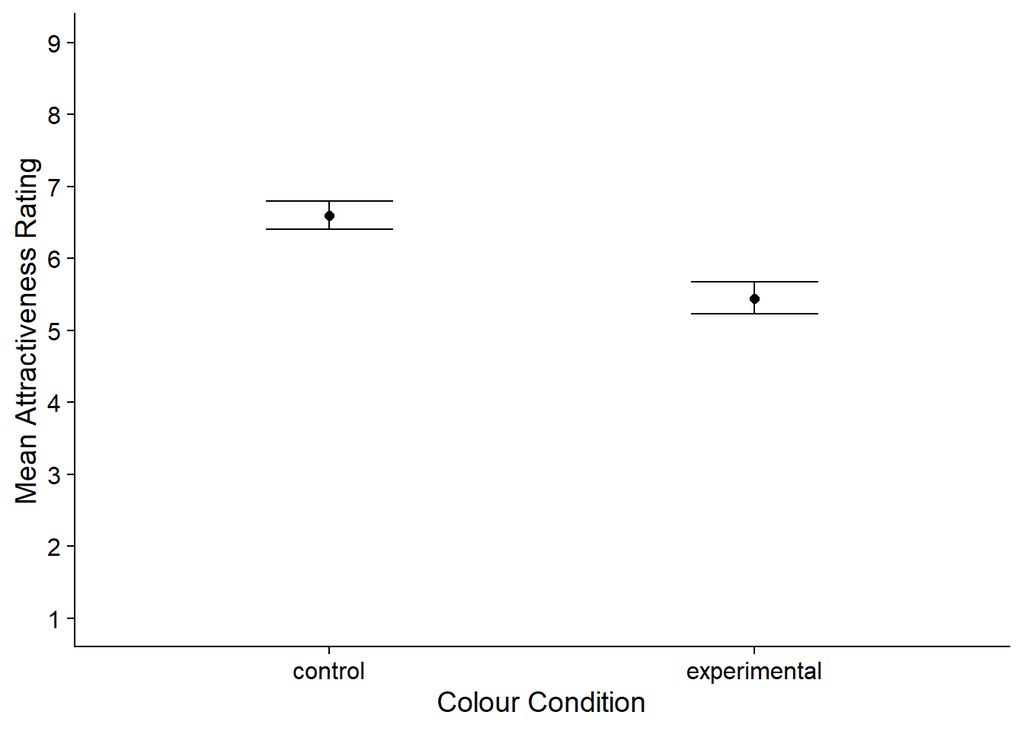

*Figure 4.* Results descriptive plot showing mean ratings of attractiveness as a function of colour. Error bars are indicated by horizontal line.

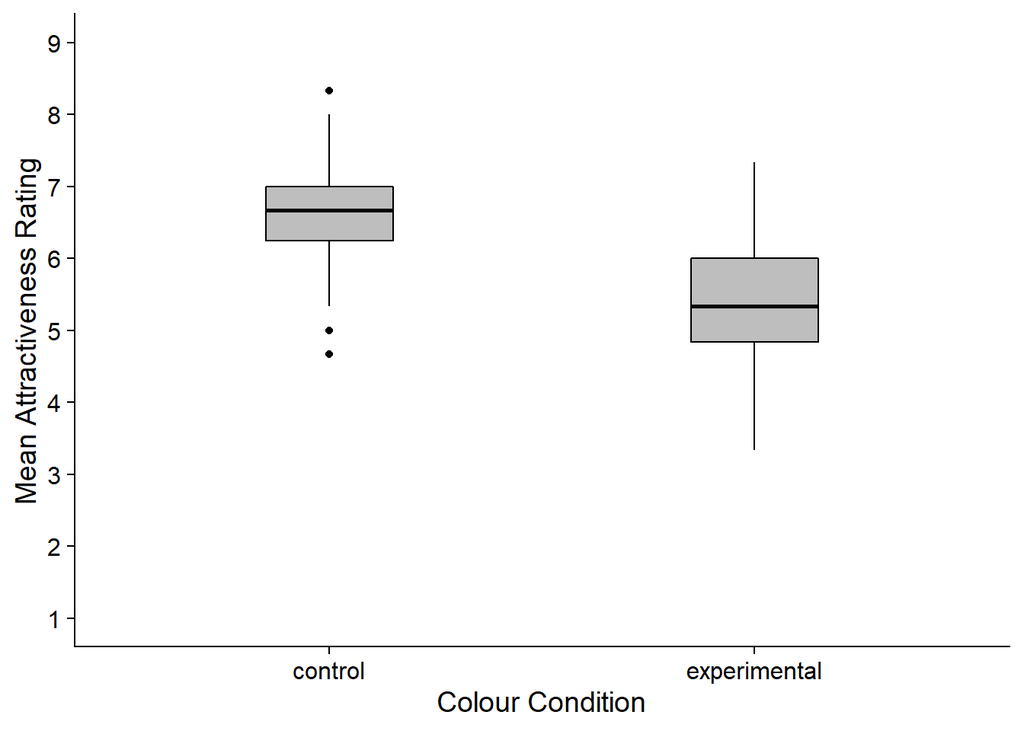

*Figure 5.* Secondary results descriptive boxplot showing ratings of attractiveness as a function of colour.

# Discussion

The results from this experiment do not support findings from the original study, rather present red as actually having a significant decreased response to attractiveness impressions (*Mdiff* = 1.15) compared to the control condition. It can be concluded that the participants in the two conditions represent samples from different populations which have different mean attractiveness ratings. Representative of these results the colour red *does not* have a positive influence on women’s perceived attractiveness ratings of men. These findings potentially question the validity of Elliot et al’s original study. The difference in such results may be a factor of population size disparity. The original study used a sample size of only 21 vastly smaller in scale compared to the 123 participants used to conclude the final data of this replication. 21 is tentatively too limited a population size to achieve conclusions respective the entire population. The larger participant sample makes the data attained from this experiment conspicuously more reliable.

Experiment 1 implemented by Elliot et al. has been subject to other replications questioning the validity of the data, one such from Hesslinger et al. (2015) showing no considerable effect supporting the hypothesis of correlation between red and increased attraction (Red: *M* = 5.71, *SD* = 1.70, White: *M* = 5.39, *SD* = 1.53). Furthermore, Peperkoorn et al. (2016) implemented different procedures to examine this proposed correlation from Elliot et al. and again found no evidence to support these claims; including reassigning the gender subject of the experiment to rate perceived attractiveness based on men. Prior to these replications Gregory Francis (2013) responded to “Red, Rank, and romance in women viewing men”, arguing the experiments are in an inadequate position to assert the results of the data. Francis states that due to publication bias, findings from the original study should be rejected. Continuing, Francis questions whether colour does in fact have an influence. Following this replication and promoted by previous experiments there is a strong position to conclude that the colour red does not have an influence of female attraction to men.

# References

Elliot, A.J., Niesta Kayser, D., Greitemeyer, T., Lichtenfeld, S., Gramzow, R.H., Maier, M.A., & Liu, H. (2010). Red, rank, and romance in women viewing men. *Journal of Experimentla Psychology: General, 139*(3), 399.

Francis, G. (2013). Publication bias in “Red, rank, and romance in women viewing men,” by elliot et al. (2010). *Journal of Experimental Psychology: General, 142*(1), 292-296.

Hesslinger, V.M., Goldbach, L. & Carbon, C. (2015). Men in red: A reexamination of the red-attractiveness effect. *Psychon Bull Rev 22, 1142-1148.*

Peperkoorn, l.S., Roberts, S.C., Pollet, T.V. (2016). Revisiting the Red Effect on Attractiveness and Sexual Receptivity: No Effect of the Color Red on Human Mate Preferences.